# Analysis of Gun Violence Induced Injuries and Deaths in US

Amro Quedan , Deepika Angelene Jantz , Naema Alalwachi , Vivek Bhat Hosmat  
12/12/2018

### Introduction

What is gun violence?

Gun-related violence is violence committed with the use of a gun.

Why we chose this data?

- Gun violence is a leading cause of premature death in the U.S.
- Guns kill more than 38,000 people and cause nearly 85,000 injuries each year.
- To understand the factors leading to gun violence

### About data

- The data is originally obtained from Gun Violence Archive.
- We found a partially cleansed data from kaggle.com.
- The key numeric variables that we were interested in were, number of people killed and number of people injured.
- There are quite a few geographical variables that we have considered for our analysis.

### Purpose

- Do changes in the regulations related to the guns have an impact on the gun violations?
- How does the gun violations vary with the population of the state? Our assumption to start with is, Higher population will have higher gun violations.
- Is there a variation in number of incidents weekdays/weekends?
- Is there a seasonality influence on the number of incidents?
- Is there a pattern in the places at which the incidents have taken place?

### Data Preparation

- We aggregated the number of people injured and killed by state and then grouped by month, quarter and year for our analysis.
- We lowered the sate name case to merge our data to make a spatial polygons data frame.
- We also extracted all the incidents of occurrence based on the days of the week to understand if there is a daily pattern of gun violence.
- Once we had the aggregated data set, we melted the data by considering the ID to be date wise.

### Shortcomings

- For the year 2013, the data has an incident recorded only when there are 4 or more people injured or killed in an incident
- For the year of 2018, the data is available only till March of 2018.
- The data does not distinguish between the shooter and the victim in an incident
- Not all the data is available for Type of gun used in an incident and the place at which the incident occurred.

### Summary of our data

| Year | Sum Killed | Sum Injured | Avg.Killed | Avg.Injured | Sd.Killed | Sd.Injured |
| --- | --- | --- | --- | --- | --- | --- |
| 2014 | 12557 | 23002 | 0.24 | 0.44 | 0.50 | 0.70 |
| 2015 | 13484 | 26967 | 0.25 | 0.50 | 0.51 | 0.72 |
| 2016 | 15066 | 30580 | 0.26 | 0.52 | 0.54 | 0.75 |
| 2017 | 15511 | 30703 | 0.25 | 0.50 | 0.51 | 0.71 |
| 2018 | 3533 | 6171 | 0.26 | 0.45 | 0.53 | 0.67 |

### How has the number of incidents varied Year-on-Year?

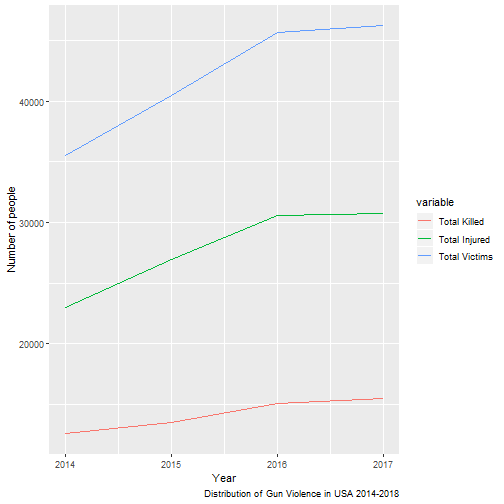

### How has the number of incidents varied by day of the week?

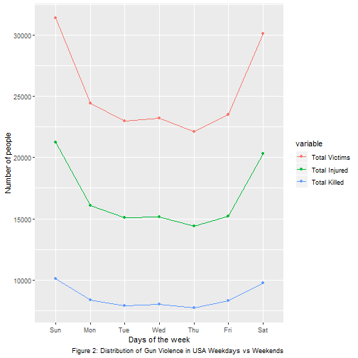

### Number of Incidents over quarters

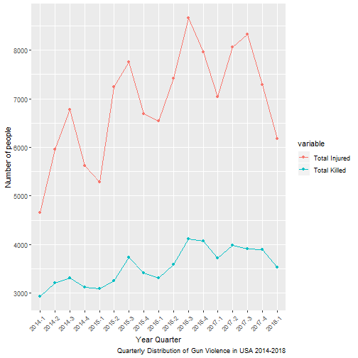

### Do changes in Gun Laws impact the gun violence at all?

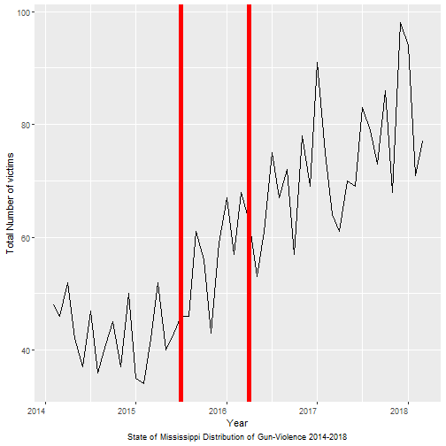

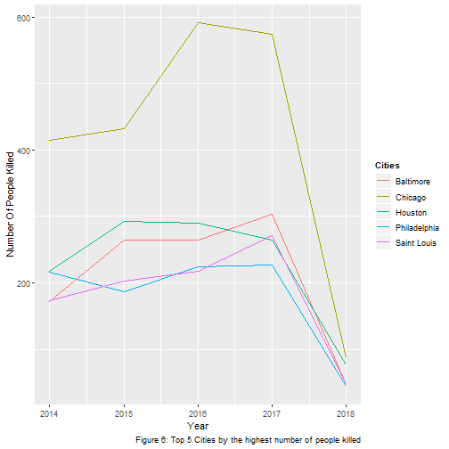

### Geographical Mapping - Number of Incidents

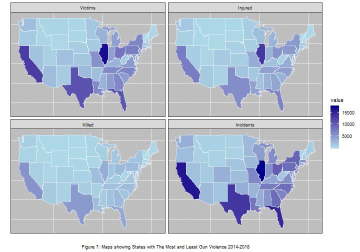

### Locations with highest frequency - Incidents

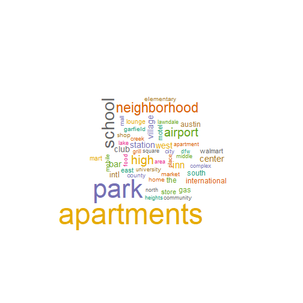

### Arima Forecasting Model - Number of Incidents for Illinois

Equation for the forecasting model:

Seasonal: \( Y_{t}-Y{t-1}= \tau(Y_{t-1}-Y_{t-2})+e_{t} \)

### Forecasting Model

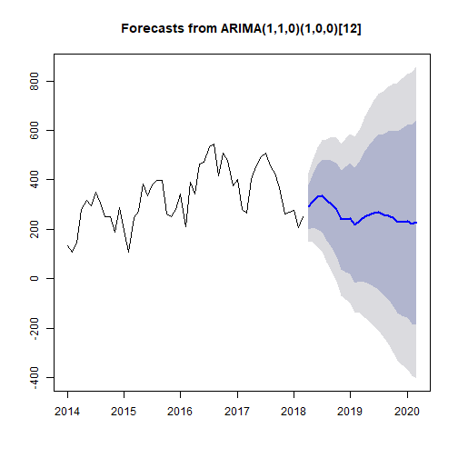

### Future work

- Analysis on how the incidents vary with number of law enforcement personnel in each state.
- Analysis on what are the gun laws and how it affects the number of incidents due to gun violence in each states.